# General steps for feature extraction from an image

## Pre-processing

- Before feature extraction, it is important to pre-process the image to improve its quality and remove any unnecessary information. This may include cropping, resizing, and normalization.

## Feature selection

- There are different types of features that can be extracted from an image such as color, texture, shape, and edges. The choice of features depends on the specific problem at hand. For instance,shapes may be important, while in image classification, texture may be more relevant

## Feature extraction

- Once the features have been selected, they can be extracted from the image using techniques such as histogram of oriented gradients (HOG)

## Feature representation

- Feature representation: The extracted features may need to be further represented in a more compact form for efficient processing. This can be achieved through techniques such as Histogram.

## Classification

- Finally, the extracted and represented features can be used to classify or recognize the image using machine learning algorithms such as support vector machines (SVM), decision trees, or neural networks

# Import Libraries

```python
import os # OS is needed to interacting with the operating System
import skimage.feature as skfeat # skfeat is used for HOG feature extraction
import skimage.io as skio # skio module is used for loading the images
import numpy as np # This is to convert the array into Numpy array
import matplotlib.pyplot as plt # This Library is used to Plot a Histogram of the extarcted HOG Features
```

# Load Datasets

```python
# folder_paths = ['/content/drive/MyDrive/DATASETS/MACHINE _LEARNING/flowers/daisy',
#                 '/content/drive/MyDrive/DATASETS/MACHINE _LEARNING/flowers/dandelion',
#                 '/content/drive/MyDrive/DATASETS/MACHINE _LEARNING/flowers/rose',
#                 '/content/drive/MyDrive/DATASETS/MACHINE _LEARNING/flowers/sunflower',
#                 '/content/drive/MyDrive/DATASETS/MACHINE _LEARNING/flowers/tulip']

## We have 5 Different types of Flower images. Means 5 Types of flowers (Daisy, Dandelion, Rose, Sunflower, Tulip).
## But for this small survey, we only took one type of flower Called Daisy
folder_path = '/content/drive/MyDrive/DATASETS/MACHINE _LEARNING/flowers/daisy' # Defining the path to the folder containing the images
# Get a list of all image file names in the folder
file_names = os.listdir(folder_path) # Listing all the image file names in the folder
```

# Feature Extraction(HOG Shape)

## HOG Shape :

- Compute the gradient magnitude and orientation at each pixel in the image.
- Group the pixels into cells (small, overlapping regions of the image).
- Construct a histogram of gradient orientations for each cell.
- Normalize the histograms for each cell by the sum of the magnitudes of the gradients in the cell
- Concatenate the histograms for all cells in the image to form the final feature vector

```python
image_shape = 0;
hog_features = []
# Loop over all images in the folder and extract HOG features
for file_name in file_names:
    # Load the image
    ## Okay, There are 764 items for Daisy Flower folder, Now, we are making a complete and unique path of individual images
    img_path = os.path.join(folder_path, file_name)
    img = skio.imread(img_path, as_gray=True) # Convert the images to grayscale(reduce the dimensionality & focus on texture not colors) before reading(loading) them
    # img is the 2D array here
    image_shape = img.shape
    # Extract HOG features
    hog_feats = skfeat.hog(img)
    hog_features.append(hog_feats) # Storing in an array to use them for histogram in future

    # Print the image name and HOG feature shape
    print(f"{file_name:<30} {hog_feats.shape}") # hog_feats.shape is the
print("Image Dimension = ",image_shape)
```

```
14333681205_a07c9f1752_m.jpg   (47628,)
14332947164_9b13513c71_m.jpg   (58968,)
14330343061_99478302d4_m.jpg   (52164,)
14221848160_7f0a37c395.jpg     (189540,)
14307766919_fac3c37a6b_m.jpg   (38556,)
14272874304_47c0a46f5a.jpg     (189540,)
14245834619_153624f836.jpg     (189540,)
14221836990_90374e6b34.jpg     (189540,)
14264136211_9531fbc144.jpg     (160380,)
14219214466_3ca6104eae_m.jpg   (45360,)
14167534527_781ceb1b7a_n.jpg   (86184,)
14167543177_cd36b54ac6_n.jpg   (86184,)
16492248512_61a57dfec1_m.jpg   (45360,)
16401288243_36112bd52f_m.jpg   (63504,)
16291797949_a1b1b7c2bd_n.jpg   (73872,)
163978992_8128b49d3e_n.jpg     (92340,)
16360180712_b72695928c_n.jpg   (86184,)
16482676953_5296227d40_n.jpg   (83106,)
16323838000_3818bce5c6_n.jpg   (45360,)
16161045294_70c76ce846_n.jpg   (73872,)
162362896_99c7d851c8_n.jpg     (92340,)
162362897_1d21b70621_m.jpg     (56700,)
16121105382_b96251e506_m.jpg   (38556,)
15813862117_dedcd1c56f_m.jpg   (45360,)
15760811380_4d686c892b_n.jpg   (73872,)
158869618_f1a6704236_n.jpg     (95418,)
15853110333_229c439e7f.jpg     (189540,)
16056178001_bebc2153fe_n.jpg   (63504,)
15784493690_b1858cdb2b_n.jpg   (86184,)
16025261368_911703a536_n.jpg   (86184,)
16020253176_60f2a6a5ca_n.jpg   (73872,)
15760153042_a2a90e9da5_m.jpg   (63504,)
154332674_453cea64f4.jpg       (257580,)
15029936576_8d6f96c72c_n.jpg   (86184,)
15100730728_a450c5f422_n.jpg   (34020,)
15327813273_06cdf42210.jpg     (189540,)
15306268004_4680ba95e1.jpg     (189540,)
15207766_fc2f1d692c_n.jpg      (73872,)
153210866_03cc9f2f36.jpg       (213840,)
14921511479_7b0a647795.jpg     (160380,)
```

[output cut: 710 more lines]

```
8887005939_b19e8305ee.jpg      (160380,)
8759177308_951790e00d_m.jpg    (45360,)
8932490012_cc08e690ba_n.jpg    (89262,)
99306615_739eb94b9e_m.jpg      (45360,)
9611923744_013b29e4da_n.jpg    (73872,)
9922116524_ab4a2533fe_n.jpg    (86184,)
9595857626_979c45e5bf_n.jpg    (73872,)
9593034725_0062f0d24e_n.jpg    (73872,)
9489270024_1b05f08492_m.jpg    (52164,)
9467543719_c4800becbb_m.jpg    (49896,)
9529916092_de70623523_n.jpg    (86184,)
9515186037_3be48fe68f.jpg      (189540,)
9496209717_25a6ebdab6_m.jpg    (63504,)
9350942387_5b1d043c26_n.jpg    (73872,)
Image Dimension =  (211, 320)
```

### Convert the list of HOG features to a numpy array

We used numpy array because numpy array can manipulate large multi-dimensional arrays of data

```python
hog_features = np.array(hog_features) # This is to plot the Histogram
```

# Plot a histogram of the HOG features

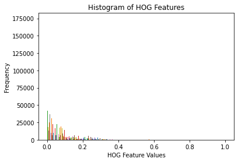

```python
plt.hist(hog_features.flatten(), bins=50)
plt.xlabel('HOG Feature Values')
plt.ylabel('Frequency')
plt.title('Histogram of HOG Features')
plt.show()
```

# Now Save the Image for further showcasing

```python
plt.savefig("histogram.svg")
```